# 05-exercises

Ai Sasho

2016-05-07

## Reading:

- **APM** Chapter 8.1-8.5 “Regression Trees and Rule-Based Models” (25 pages)
- **APM** Chapter 14.1-14.5 “Classification Trees and Rule-Based”
- Read about trainControl

## Exercise 1: GermanCredit

Revisit the GermanCredit data. Use `caret` to build models of `Class` using the following techniques:

- glm
- rpart
- knn
- party::ctree
- randomForest
- A method of your choice from the Caret Model List (you will need to install any dependencies)

Save the caret objects with the names provided.

```r
library(caret)
data(GermanCredit)

control <-  trainControl( method="boot", number=5, classProb=TRUE, savePrediction=TRUE )

fit.glm <- train(Class ~ ., data=GermanCredit, method="glm", family="binomial", trControl=control, tuneLength=20)
fit.knn <- train(Class ~ ., data=GermanCredit, method="knn", trControl=control, tuneLength=20)

fit.rpart <- train(Class ~ ., data=GermanCredit, method="rpart", trControl=control, tuneLength=20)
fit.myown <- train(Class ~ ., data=GermanCredit, method="gpls", trControl=control)
```

- Compare the models using `caret::confusionMatrix`
- Comparing the models Using the `pROC` packages
- create ROC curves for the models

Show your work!

```r
# Confusion matrix
table(fit.glm$pred$pred, fit.glm$pred$obs) %>% confusionMatrix()
```

```
## Confusion Matrix and Statistics
##
##
##         Bad Good
##   Bad   252  201
##   Good  304 1086
##
##                Accuracy : 0.726
##                  95% CI : (0.705, 0.7463)
##     No Information Rate : 0.6983
##     P-Value [Acc > NIR] : 0.004902
##
##                   Kappa : 0.3136
##  Mcnemar's Test P-Value : 5.654e-06
##
##             Sensitivity : 0.4532
##             Specificity : 0.8438
##          Pos Pred Value : 0.5563
##          Neg Pred Value : 0.7813
##              Prevalence : 0.3017
##          Detection Rate : 0.1367
##    Detection Prevalence : 0.2458
##       Balanced Accuracy : 0.6485
##
##        'Positive' Class : Bad
##
```

```r
table(fit.knn$pred$pred, fit.knn$pred$obs) %>% confusionMatrix()
```

```
## Confusion Matrix and Statistics
##
##
##          Bad  Good
##   Bad   1784  2709
##   Good  9476 23471
##
##                Accuracy : 0.6745
##                  95% CI : (0.6698, 0.6793)
##     No Information Rate : 0.6993
##     P-Value [Acc > NIR] : 1
##
##                   Kappa : 0.0663
##  Mcnemar's Test P-Value : <2e-16
##
##             Sensitivity : 0.15844
##             Specificity : 0.89652
##          Pos Pred Value : 0.39706
##          Neg Pred Value : 0.71239
##              Prevalence : 0.30075
##          Detection Rate : 0.04765
##    Detection Prevalence : 0.12001
##       Balanced Accuracy : 0.52748
##
##        'Positive' Class : Bad
##
```

```r
table(fit.rpart$pred$pred, fit.rpart$pred$obs) %>% confusionMatrix()
```

```
## Confusion Matrix and Statistics
##
##
##          Bad  Good
##   Bad   3850  3759
##   Good  7470 22521
##
##                Accuracy : 0.7014
##                  95% CI : (0.6967, 0.706)
##     No Information Rate : 0.6989
##     P-Value [Acc > NIR] : 0.1545
##
##                   Kappa : 0.2174
##  Mcnemar's Test P-Value : <2e-16
##
##             Sensitivity : 0.3401
##             Specificity : 0.8570
##          Pos Pred Value : 0.5060
##          Neg Pred Value : 0.7509
##              Prevalence : 0.3011
##          Detection Rate : 0.1024
##    Detection Prevalence : 0.2024
##       Balanced Accuracy : 0.5985
##
##        'Positive' Class : Bad
##
```

```r
table(fit.myown$pred$pred, fit.myown$pred$obs) %>% confusionMatrix()
```

```
## Confusion Matrix and Statistics
##
##
##         Bad Good
##   Bad   374  578
##   Good 1447 3187
##
##                Accuracy : 0.6375
##                  95% CI : (0.6247, 0.6501)
##     No Information Rate : 0.674
##     P-Value [Acc > NIR] : 1
##
##                   Kappa : 0.0591
##  Mcnemar's Test P-Value : <2e-16
##
##             Sensitivity : 0.20538
##             Specificity : 0.84648
##          Pos Pred Value : 0.39286
##          Neg Pred Value : 0.68774
##              Prevalence : 0.32599
##          Detection Rate : 0.06695
##    Detection Prevalence : 0.17043
##       Balanced Accuracy : 0.52593
##
##        'Positive' Class : Bad
##
```

```r
# ROC
library(pROC)
```

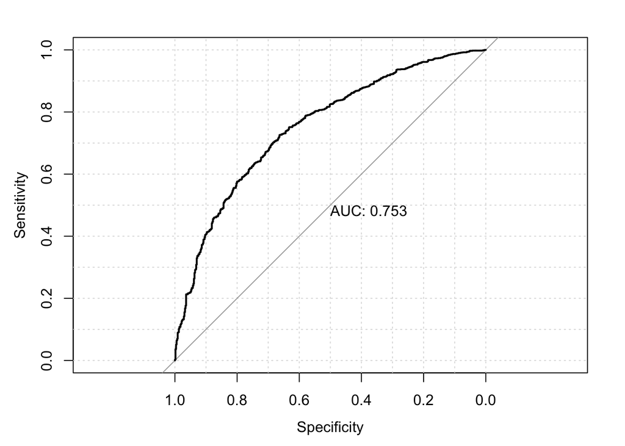

```
##
## Call:
## roc.default(response = fit.glm$pred$obs, predictor = fit.glm$pred$Bad,     auc = TRUE)
##
## Data: fit.glm$pred$Bad in 556 controls (fit.glm$pred$obs Bad) > 1287 cases (fit.glm$pred$obs Good).
## Area under the curve: 0.7527
```

```r
roc.fit.glm <- roc(fit.glm$pred$obs, fit.glm$pred$Bad, auc=TRUE )
roc.fit.glm %>% plot( print.auc=TRUE, grid=TRUE)
```

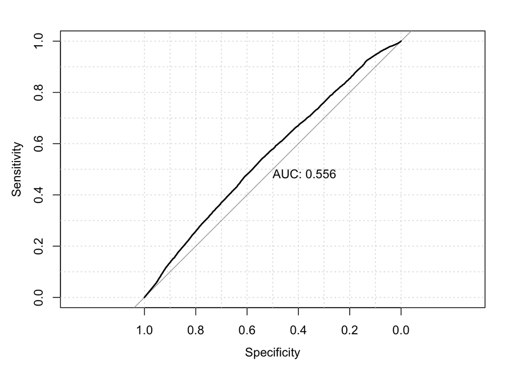

```
##
## Call:
## roc.default(response = fit.knn$pred$obs, predictor = fit.knn$pred$Bad,     auc = TRUE)
##
## Data: fit.knn$pred$Bad in 11260 controls (fit.knn$pred$obs Bad) > 26180 cases (fit.knn$pred$obs Good).
## Area under the curve: 0.556
```

```r
roc.fit.knn <- roc(fit.knn$pred$obs, fit.knn$pred$Bad, auc=TRUE )
roc.fit.knn %>% plot( print.auc=TRUE, grid=TRUE)
```